# microenvironment

2024-12-18

Working from Kling, Baer, Ackerly. 2024. A Tree’s view of the terrain: downscaling bioclimate variables to high resolution using a novel multi-level species distribution model. Ecography

- We call this biologically inferred fine-scale climate variation “bioclimate”, and we call the modeling method “bioclimate inference from species’ high-resolution occurrence patterns’ (BISHOP)
- A BISHOP model assumes that macroclimate and micro-physiography shape an unmeasured bioclimate variables that then drives occurrence probability.
- The climate downscaling submodel predicts a higher-resolution version of a macroclimate variable, creating its corresponding bioclimate variable by adding an offset (or delta value) that is a function of fine-scale physiography (e.g. terrain, soils, vegetation).
- Variables in model: northness, eastness, exposure, elevational position, total annual precipitation, max temperature of the warmest month and minimum temperature of the coldest month, mean annual temperature, total annual precipitation
- Model includes a climate downscaling component that models a latent bioclimate variable as a function of macroclimate and topography, and a niche component that models species occurrences as a function of bioclimate.
- Basic assumptions of the model, (1) the difference between a site’s marcoclimate and its bioclimate is a function of topography, (2) each macroclimate variables has a corresponding bioclimate variables, and these are equal in a flate site, (3) at a given site, each topographic variable has a linear modifying effect on each macroclimate variable, (4) these effects vary among locations as a spline function of the modifier variables.

To generate example map of Idaho in manuscript:

- fitted multi-species model to generate downscaled tree-sepcies bioclimate data for an example landscape in southern Idaho.
- The inputs were the same macrocliamte and wind data used to fit the model, and a 10 m elevation raster.
- Used bilinear interpolation to create smoothed macroclimate variables at 10 m resolution, and used elevation to calculate the four topographic variables at 10 m resolution.
- Using the fitted model parameters, we then calculated bioclimate high temperature, low temperature, and moisture on the 10 m grid.

This process can be easily replicated using an R package (Data availability section) that lets users input elevation data for any landscape in our study area to generate bioclimate estimates for North American trees based on coefficients from the multi-species model. To yield consistent results, elevation data should have a resolution similar to our input data (10-100 m), and cover an area of multiple square kilometers.

Link to github for R package https://github.com/matthewkling/topoclimate.pred

Load R package

```r
#devtools::install_github("matthewkling/topoclimate.pred")
```

```r
library(topoclimate.pred)
```

Lat/Long are Easting and Northing. They are in NE State Plane Coordinates. Need to convert these to same NAD83 crs, same as DEM. Convert the corners of the plot first.

```r
easting = c(498282.6473,498127.8007,498788.1970,498633.3845)
northing = c(327208.3156,327533.3118,327449.1881,327774.1614)
nio.corners = data.frame(easting,northing)
```

Code for NAD83 is 4269 for DEM, code is 32104 for Nebrasaka State Plane.

```r
coordinates(nio.corners) = ~ easting + northing
proj4string(nio.corners) = CRS("+init=epsg:32104")
latlong.corners = data.frame(spTransform(nio.corners, CRS("+init=epsg:4269")))
```

Read in elevation raster for Niobrara

Source: https://apps.nationalmap.gov/downloader/#/

Metadata: https://www.sciencebase.gov/catalog/item/647ac9a9d34eac007b5234fb

```r
elev <- raster("../Raw.Data/USGS_13_n43w101_20220726.tif")
names(elev) <- "elevation"
```

Crop to focus on Niobrara plot

```r
ext <- extent(-100.03, -100.01, 42.77, 42.79)
et <- crop(elev, ext)
```

Make a quick terrain map of the entire landscape

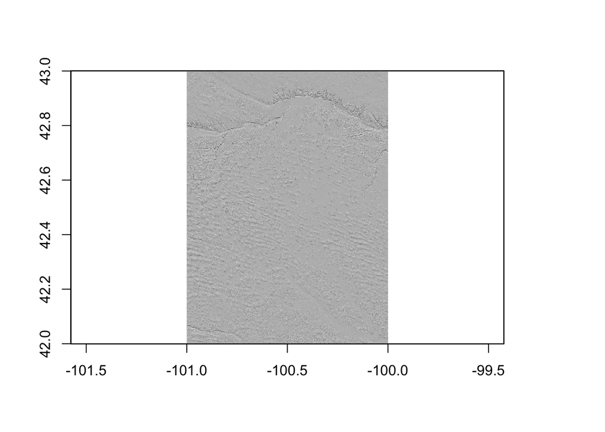

```r
hillshade <- hillShade(terrain(elev, "slope"), terrain(elev, "aspect"))
plot(hillshade, col = colorRampPalette(c("black", "white"))(50), legend = F)
```

Terrian map of cropped area

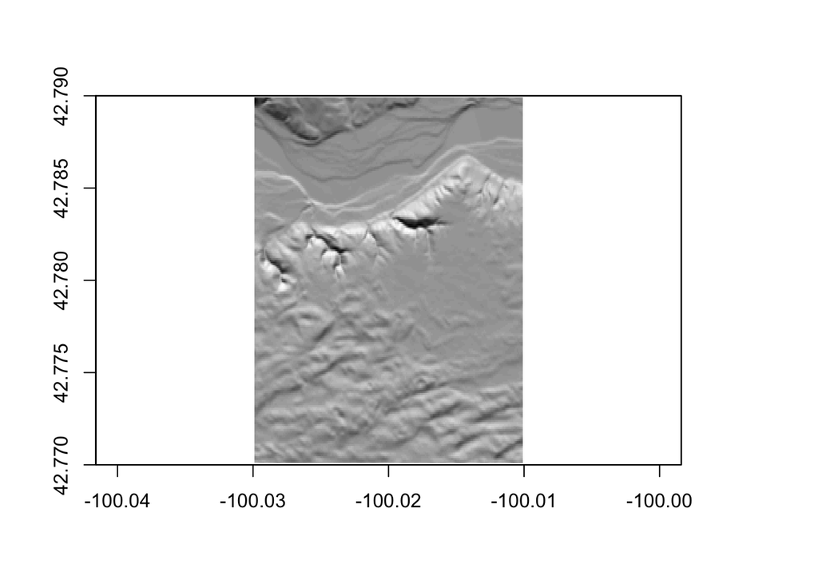

```r
hillshade.crop <- hillShade(terrain(et, "slope"), terrain(et, "aspect"))
plot(hillshade.crop, col = colorRampPalette(c("black", "white"))(50), legend = F)
```

Get microclimate for Niobrara. Set include_inputs = TRUE to get macroclimate variables to output. Took 10 minutes to run.

```r
clim <- bioclimate(et, include_inputs = TRUE)
```

```
## Calculating biogially effective topoclimate
## (Note: you can safely ignore any 'attempt to apply non-function' error messages;
## see https://github.com/rspatial/terra/issues/30 for more info on these gremlins.)
```

```
## ... computing northness & eastness ...
```

```
## ... computing windward exposure ...
```

```
## ... computing elevational position ...
```

```
## ... preparing macroclimate ...
```

```
## ... computing deltas ...
```

```
## ... compiling bioclimate estimates ...
```

Save RasterStack

```r
writeRaster(clim, filename="../Formatted.Data/niobrara.micro.tif", options="INTERLEAVE=BAND", overwrite=TRUE)
```

Plotting. Macro climate variables are monthly data extracted from CHELSA representing climatic averages from 1979-2009 at 1km resolution. From these, they derived total annual precipitation (bio12), mean annual temperature (bio1), maximum temperature of the warmest month (bio5), and minimum temperature of the coldest month (bio6). Northness and Eastness were calculated from slope and aspect. Windward exposure represents how a plot’s windiness is expected to deviate from the average windiness of level sites on the local landscape. mTPI measures how a site’s elevation compares to the elevation of the surrounding neighborhood, with positive values for hilltops and negative values for valley bottoms.

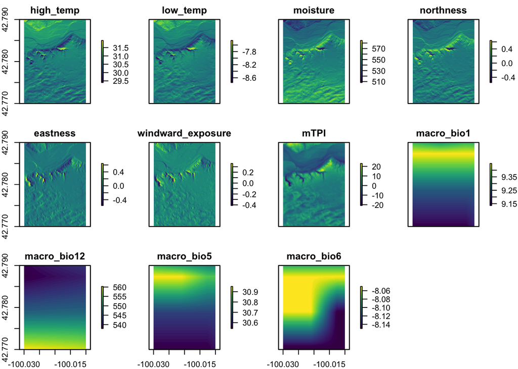

```r
plot(clim, col = viridis::viridis_pal()(50))
```

### Extracting microclimate data for a few niobrara trees.

Read in Niobrara data points

```r
nio.dat = read.csv("../Raw.Data/20220829_NVP_allStems_final-toJS_EN.csv", row.names = 1)
```

Get info for trees close to microclimate stations from Bailey’s data

```r
trees = nio.dat %>%
  filter(PtID %in% c(1808008,1313058,1909036,1413015,2213001,1211010,1807015)) %>%
  distinct(Easting, Northing, .keep_all = TRUE)
```

```r
tree.coords = trees %>%
  select(Easting, Northing)
coordinates(tree.coords) = ~ Easting + Northing
proj4string(tree.coords) = CRS("+init=epsg:32104")
trees.lat.long = data.frame(spTransform(tree.coords, CRS("+init=epsg:4269")))
```

Extract data for these trees

```r
trees.lat.long.2 = trees.lat.long[,c(1:2)]
tree.clim = raster::extract(clim,trees.lat.long.2)
colnames(tree.clim) = c("high_temp_C","low_temp_C","moisture_mm","northness","eastness","windward_exposure","mTPI","macro_bio1_mean_annual_temp_C","macro_bio12_total_annual_precip_mm","macro_bio5_max_temp_warm_month_C","macro_bi06_min_temp_cold_month_C")
tree.clim.2 = cbind(trees,tree.clim)
```

```r
tree.clim.2$local = c("Low Canyon East","Low Canyon Botton","Low Canyon West",
                      "High Canyon East","Hihg Canyon Bottom","High Canyon West","Upland")
```